# Chr21 Sample Filtering: F7

Harrison Ostridge

16/06/2021

I end up identifying the same outliers as Claudia did and just remove those.

#### Setup

```r
rm(list=ls())
knitr::opts_knit$set(root.dir = '~/OneDrive - University College London/Projects/Ostridge_PanAf/sample_filtering/chr21/')
```

#### Library

```r
library(dplyr)
library(data.table)
library(ggplot2)
library(ggrepel)
library(readxl)
library(plyr)
library(tidyr)
library(stringr)
library(igraph)
library(RColorBrewer)
library(grid)
library(gridExtra)
library(fields)
library(maps)
library(mapdata)
library(mapplots)
library(RColorBrewer)
library(MCMCpack)
```

#### Read in data

```r
# Read in metadata
f6_chr21=read.csv("output/f6/f6.chr21.metadata.csv", check.names = FALSE)
f6_exome=read.csv("output/f6/f6.metadata.csv", check.names = FALSE)
## Ensure it is in the correct order
f6_chr21=f6_chr21[order(f6_chr21$Sample),]
```

## Population Structure

### PCAngsd

```r
plot.PCA=function(subsps, meta.data, input.dir, output.file=NULL, label=NULL, return.df=FALSE){
  # Create list to store result data frames in
  results=list()
  # BAM file lists are always given in alphabetical order (with respect to sample name) so it is important to ensure the samples are in this order
  meta.data=meta.data[order(meta.data$Sample),]
  # Add label column, if no column is provided a blank label column is used
  meta.data$label=''
  if(!is.null(label)){meta.data$label=meta.data[[label]]}
  # Loop over each subspecies provided
  for(subsp in subsps){
    title=""
    meta.data.subsp=meta.data
    # Subspecies options
    if(subsp=="c"){title="Central"}
    if(subsp=="e"){title="Eastern"}
    if(subsp=="n"){title="Nigeria-Cameroon"}
    if(subsp=="w"){title="Western"}
    if(subsp=="all"){title="All Samples"
      # Group defines how to draw polygons
      group="Subspecies"
      input=paste0(input.dir,"chr21.f6.", subsp,".cov")}
    if(subsp != "all"){
      # Group defines how to draw polygons
      group="Site"
      input=paste0(input.dir, subsp,"/chr21.f6.", subsp,".cov")
      if(title!=""){meta.data.subsp=meta.data[meta.data$Subspecies==title,]}}
    # Read in PCAngsd output
    cov=read.table(input)
    pcs=eigen(cov)
    # Select columns corresponding to PC1 and PC2
    pc1.pc2=as.data.frame(pcs$vectors[,1:2])
    colnames(pc1.pc2)=c("f6.PC1", "f6.PC2")
    # Add PC1 and PC2 columns to metadata
    ## The order of samples in PCAngsd output should be alphabetical as the BAM file lists were written in this order
    pc1.pc2=cbind(meta.data.subsp, pc1.pc2)
    # Percentage variance explained by PCs
    PC1.percent=pcs$values[1]/sum(pcs$values)*100
    PC2.percent=pcs$values[2]/sum(pcs$values)*100
    # Plot
    PC1.lab=paste("PC1 (", round(PC1.percent,digits = 2),"%)")
    PC2.lab=paste("PC2 (", round(PC2.percent,digits = 2),"%)")
    find_hull=function(pc1.pc2) pc1.pc2[chull(pc1.pc2[,'f6.PC1'], pc1.pc2[,'f6.PC2']), ]
    hulls=ddply(pc1.pc2, group, find_hull)
    # Plot all samples
    if(subsp=="all"){
      plot=ggplot(pc1.pc2, aes(x=f6.PC1, y=f6.PC2, fill=Subspecies, colour=Subspecies, label = label)) +
        theme_minimal()+
        geom_point(aes(shape=Subspecies), size = 2) +
        geom_text_repel(size = 3, min.segment.length = unit(0.1, "lines"), show.legend = FALSE) +
        geom_polygon(data = hulls, alpha = 0.5) +
        theme(panel.grid.major = element_blank(), panel.grid.minor = element_blank(), legend.key.size = unit(0.4, "cm"), plot.title = element_text(hjust = 0.5)) +
        guides(fill=guide_legend(ncol=1)) +
        labs(x=paste(PC1.lab), y=paste(PC2.lab)) +
        ggtitle(title) +
        scale_fill_manual(values = c('green3', 'darkorange', 'red', 'blue')) +
        scale_color_manual(values = c('green3', 'darkorange', 'red', 'blue')) +
        scale_shape_manual(values=0:4)
    }
    # Plot individual subspecies
    else{
      plot=ggplot(pc1.pc2, aes(x=f6.PC1, y=f6.PC2, fill=Site, colour=Site, label = label)) +
        theme_minimal()+
        geom_point(aes(shape=Site), size = 2) +
        geom_text_repel(size = 3, min.segment.length = unit(0.1, "lines"), show.legend = FALSE) +
        geom_polygon(data = hulls, alpha = 0.5) +
        theme(panel.grid.major = element_blank(), panel.grid.minor = element_blank(), legend.key.size = unit(0.4, "cm"), plot.title = element_text(hjust = 0.5)) +
        guides(fill=guide_legend(ncol=1), shape=guide_legend(ncol=1)) +
        labs(x=paste(PC1.lab), y=paste(PC2.lab)) +
        ggtitle(title) +
        scale_shape_manual(values=rep(0:6, 10))
    }
    # If an output file is provided, write to it
    if(!is.null(output.file)){ggsave(paste0(output.file), plot=plot)}
    # Display plot
    print(plot)
    # Save metadata with PC1 and PC2 columns added for the subspecies in results list
    results[[subsp]]=pc1.pc2
  }
  # If return.df is set to TRUE, return the results list
  if(return.df==T){return(results)}
}
```

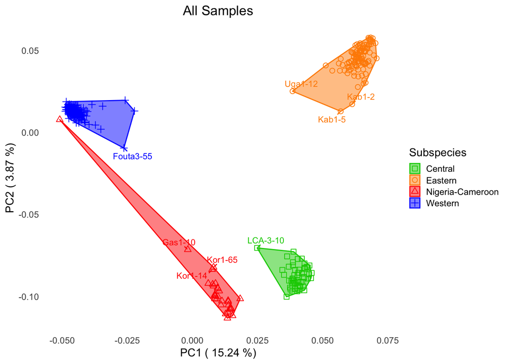

```r
chr21_all=plot.PCA("all",
         f6_chr21,
         paste0("../../pcangsd/chr21/output/chr21.f6.all_minInd.15_doMajorMinor.1_HWE.p.1e-3_snp.p.1e-6_minMAF.0.01/"),
         label="Sample",
         return.df = T)
```

```r
chr21_all$all[(chr21_all$all$Subspecies=="Nigeria-Cameroon") & (chr21_all$all$f6.PC2>0),
              c("Sample", "Site", "Subspecies", "Coverage", "Human Contamination from Chr21")]
```

```
##      Sample  Site       Subspecies Coverage Human Contamination from Chr21
## 266 Kor1-35 Korup Nigeria-Cameroon 25.78873                          0.121
```

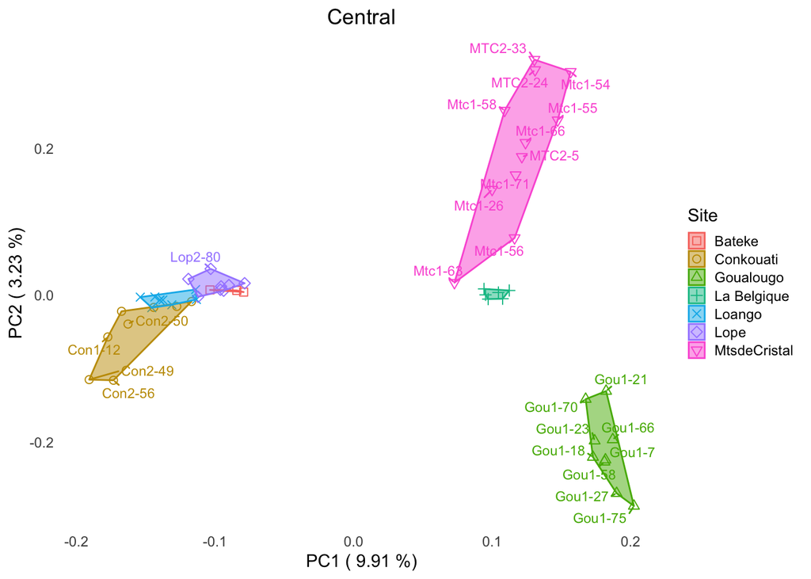

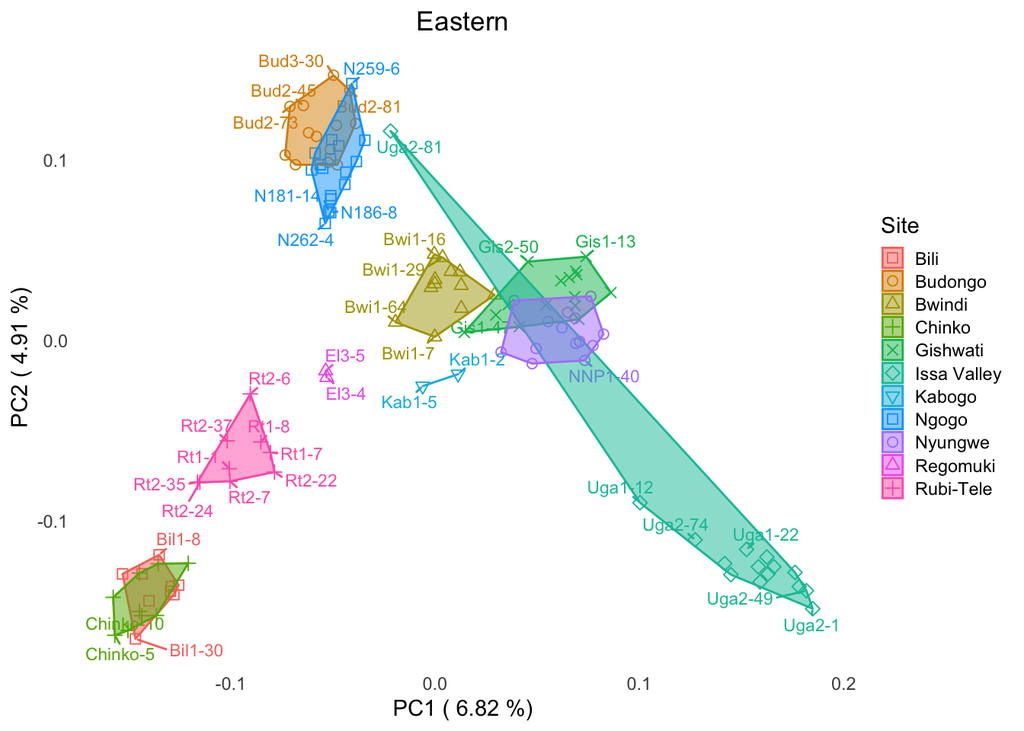

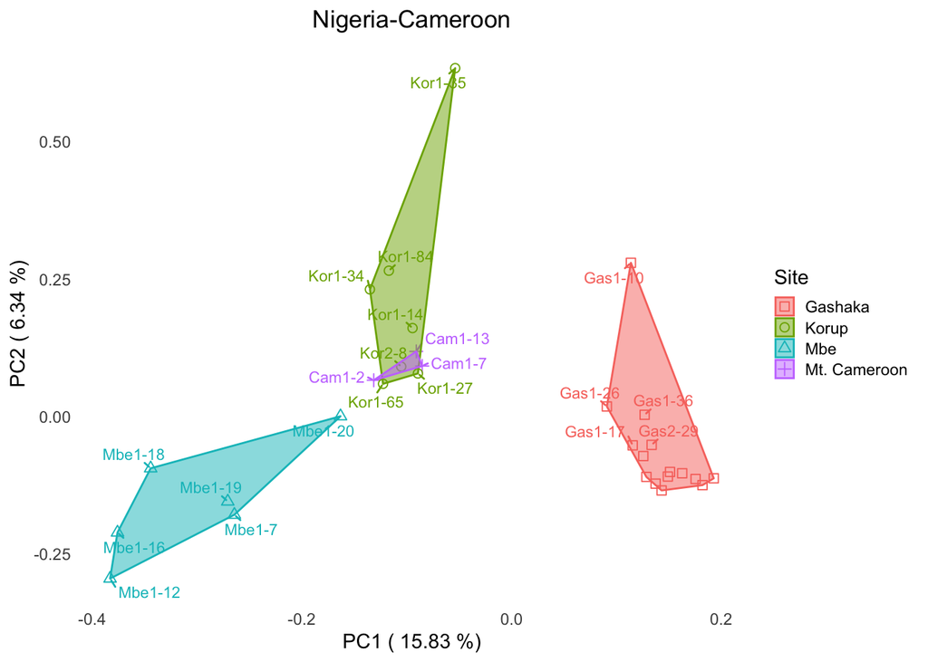

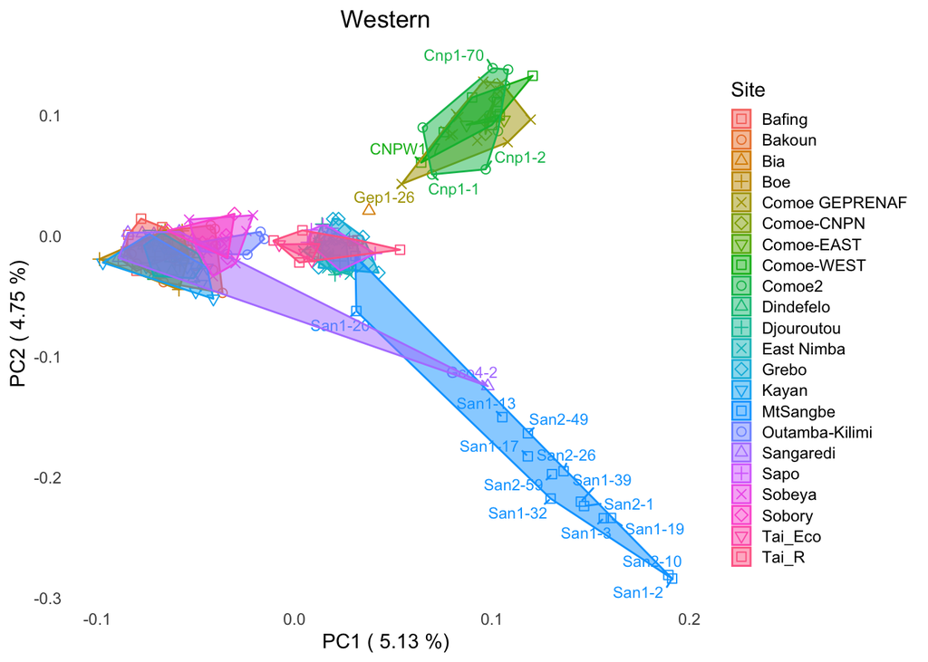

```r
chr21_subsp=plot.PCA(c("c", "e", "n", "w"),
         f6_chr21,
         paste0("../../pcangsd/chr21/output/chr21.f6.subsp_minInd.15_doMajorMinor.1_HWE.p.1e-3_snp.p.1e-6_minMAF.0.01/"),
         label="Sample",
         return.df = T)
```

NB: we see the MtSangbe-Sangaredi sample swap in westerns (Gco4-2) which we have account for and so is not a concern.

```r
chr21_subsp$e[chr21_subsp$e$Site=="Issa Valley" & chr21_subsp$e$f6.PC1<0,
              c("Sample", "Site", "Subspecies", "Coverage", "Human Contamination from Chr21")]
```

```
##      Sample        Site Subspecies Coverage Human Contamination from Chr21
## 414 Uga2-81 Issa Valley    Eastern 69.27188                          0.035
```

```r
chr21_subsp$w[chr21_subsp$w$Sample=='Gco4-2',]
```

```
##     Sample Sample Type      Site Country Subspecies Project     eDNA
## 210 Gco4-2       Feces Sangaredi  Guinea    Western   PanAf 8.731904
##     Average Fragment Size GQN (Fragmentation Score) Longitude Latitude   Phase
## 210                  2281                         4 -14.01414 11.05745 Phase-2
##     Coverage Human Contamination from Chr21 SD1...15 SD2...16 Num Position...17
## 210 5.680176                          0.067    0.006    0.129            293349
##     Main Hit BBsplit Human Contamination from Exome SD1...20 SD2...21
## 210            Chimp                          0.146    0.137    0.154
##     Num Position...22 PCA all chimps   N=728 PCA > 0.5x N=556
## 210            764991                    Yes              Yes
##     PCA  > 0.5x; No Kor1-35 N=555
## 210                           Yes
##     Samples removed after Relatedness Analysis N=89
## 210                                              No
##     PCA ssp; ADMIXTURE; SFS;FST;Het; Diversity; admixfrog. Filters: HC <1%
## 210                                                                    Yes
##     > 0.5x no related N=449 PCA ssp + recover Ngiri Bou Bia N=457
## 210    Yes              Yes                     Yes Yes        NA
##     Pairwise Gen Distance EEMS; >5X <1% HC N=213 F3; Treemix; >5X <0.5% HC
## 210                              NA           NA                        NA
##     N=205 IBD; >5X <1% HC  + related samples N=240  label     f6.PC1     f6.PC2
## 210    NA       NA                        NA    NA Gco4-2 0.09784982 -0.1245227
```

The only concern is the Issa Valley sample Uga2-81 which does not cluster with the rest. This was removed in Claudia’s paper for this reason. I think we should remove this.

```r
f7_chr21=f6_chr21[!(f6_chr21$Sample %in% c("Kor1-35","Uga2-81")),]
f7_exome=f6_exome[!(f6_exome$Sample %in% c("Kor1-35","Uga2-81")),]
```

```r
write.table(f7_exome, "output/f7/f7.metadata.csv", sep=",", row.names=FALSE, col.names=TRUE, quote=FALSE)
write.table(f7_chr21, "output/f7/f7.chr21.metadata.csv", sep=",", row.names=FALSE, col.names=TRUE, quote=FALSE)

f7_exome[f7_exome$Sample=='Gco4-2',]
```

```
##     Sample Sample.Type     Site     Country Subspecies     hDNA
## 210 Gco4-2       Feces MtSangbe Ivory Coast    Western 5.719824
##     Average.Fragment.Size GQN..Fragmentation.Score. Longitude Latitude
## 210                  2281                         4 -7.303265 8.008652
##     Method.for.hDNA.quantification Coverage Human.Contamination....
## 210                        Shotgun 14.45292                   0.153
##     SD1..Human.Contamination. SD2...Human.Contamination.
## 210                     0.116                       0.19
##     Num.Position...Human.Contamination.
## 210                              186050
##                                                                         BAM.mapped.on.target
## 210 /home/ucfajos/Scratch/data/phase1and2_exomes/BAM.mapped.on.target/Gco4-2_exome.addRG.bam
##      Community     f0.PC1 f2.pca.probem.samples Population
## 210 w.MtSangbe 0.01457543                Gco4-2 w.MtSangbe
##                                                            chr21.BAM
## 210 /home/ucfajos/Scratch/data/phase1and2_chr21/BAM/Gco4-2.addRG.bam
```

#### Number of samples

```r
freq.per.group=data.frame(table(f7_exome$Population))
sum(freq.per.group$Freq)
```

```
## [1] 412
```

```r
sum(freq.per.group[freq.per.group$Freq>=8, 'Freq'])
```

```
## [1] 385
```

#### Average coverage

```r
f5_exome=read.csv("../exome/output/f5/f5.metadata.csv", check.names = FALSE)
cat("f5 Exome\n median:",median(f5_exome$Coverage), "\n mean:", mean(f5_exome$Coverage),
    "\nf7 chr21\n median:",median(f7_chr21$Coverage), "\n mean:", mean(f7_chr21$Coverage))
```

```
## f5 Exome
##  median: 4.961617
##  mean: 9.06278
## f7 chr21
##  median: 5.22934
##  mean: 8.878292
```

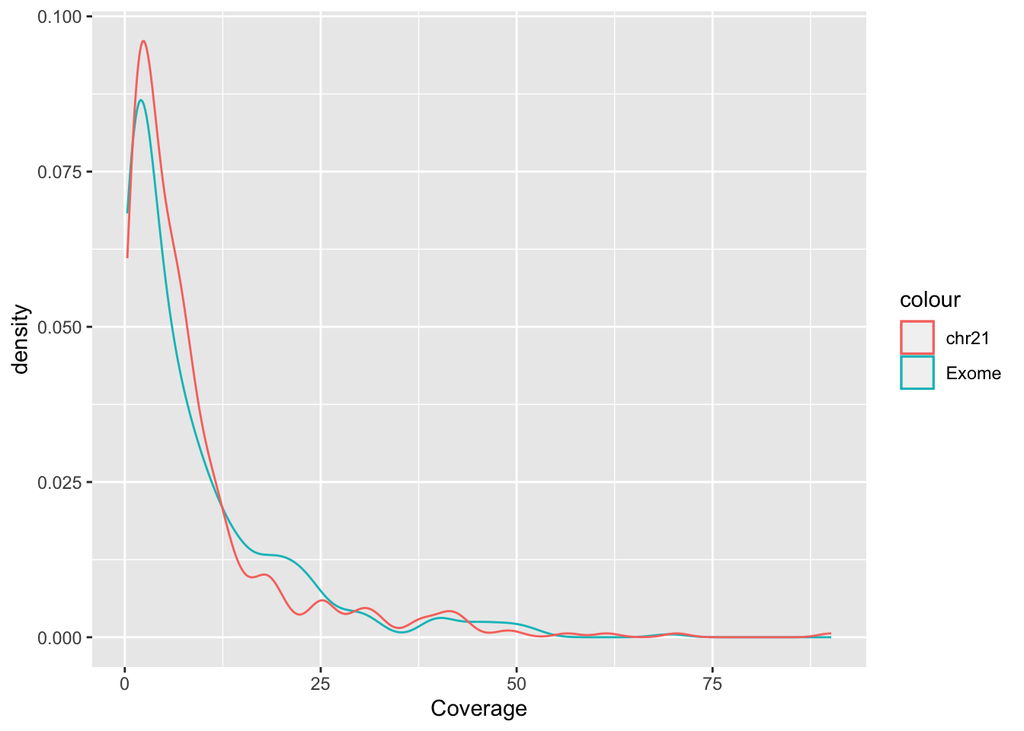

```r
ggplot(NULL)+
  geom_density(data=f5_exome, aes(x=Coverage, col="Exome"))+
  geom_density(data=f7_chr21, aes(x=Coverage, col="chr21"))
```

### Write BAM file lists

I am using the exome metadata file to write the bam file lists just because I have reassigned the sample swaps and defined populations already here.

#### All

```r
# Ensure it is ordered according to sample name
f7_exome=f7_exome[order(f7_exome$Sample),]
# All
write.table(f7_exome$chr21.BAM,
            paste0("output/bam.filelists/f7/bam.filelist.all"),
            row.names=FALSE, col.names=FALSE, quote=FALSE)
```

#### Subspecies

```r
# Central
write.table(f7_exome[f7_exome$Subspecies=="Central",]$chr21.BAM,
            paste0("output/bam.filelists/f7/bam.filelist.c"),
            row.names=FALSE, col.names=FALSE, quote=FALSE)
# Eastern
write.table(f7_exome[f7_exome$Subspecies=="Eastern",]$chr21.BAM,
            paste0("output/bam.filelists/f7/bam.filelist.e"),
            row.names=FALSE, col.names=FALSE, quote=FALSE)
# Nigeria-Cameroon
write.table(f7_exome[f7_exome$Subspecies=="Nigeria-Cameroon",]$chr21.BAM,
            paste0("output/bam.filelists/f7/bam.filelist.n"),
            row.names=FALSE, col.names=FALSE, quote=FALSE)
# Western
write.table(f7_exome[f7_exome$Subspecies=="Western",]$chr21.BAM,
            paste0("output/bam.filelists/f7/bam.filelist.w"),
            row.names=FALSE, col.names=FALSE, quote=FALSE)
```

#### Populations

```r
pops=unique(f7_exome$Population)
for(pop in pops){
  f7_exome.pop=f7_exome[f7_exome$Population==pop, ]
  write.table(f7_exome.pop$chr21.BAM,
              paste0("output/bam.filelists/f7/bam.filelist.", pop),
              row.names=FALSE, col.names=FALSE, quote=FALSE)
}
```

```bash
scp -r output/bam.filelists/f7 myriad:/home/ucfajos/analysis/phase1and2_chr21_analysis/angsd/bam.filelists/
```